# 拍拍贷数据 探索性分析

```
## [1] "/Users/Mac/Udacity/P3"
```

# 单变量分析

### 1. 你的数据集结构是什么？

```r
str(LC)
```

```
## 'data.frame':    328553 obs. of  21 variables:
##  $ ListingId       : int  126541 133291 142421 149711 152141 162641 171191 175451 182261 193831 ...
##  $ 借款金额        : int  18000 9453 27000 25000 20000 20000 3940 20000 25000 10475 ...
##  $ 借款期限        : int  12 12 24 12 6 12 6 12 12 6 ...
##  $ 借款利率        : num  18 20 20 18 16 14 18 18 16 18 ...
##  $ 借款成功日期    : Factor w/ 756 levels "2015-01-01","2015-01-02",..: 119 70 477 84 22 79 172 439 75 100 ...
##  $ 初始评级        : Factor w/ 6 levels "A","B","C","D",..: 3 4 5 3 3 1 5 2 2 3 ...
##  $ 借款类型        : Factor w/ 4 levels "APP闪电","其他",..: 2 2 3 2 4 3 4 3 2 4 ...
##  $ 是否首标        : Factor w/ 2 levels "否","是": 1 1 1 1 1 1 1 1 1 1 ...
##  $ 年龄            : int  35 34 41 34 24 36 27 32 33 25 ...
##  $ 性别            : Factor w/ 2 levels "女","男": 2 2 2 2 2 2 1 2 1 2 ...
##  $ 手机认证        : Factor w/ 2 levels "成功认证","未成功认证": 1 2 1 1 1 1 1 1 1 1 ...
##  $ 户口认证        : Factor w/ 2 levels "成功认证","未成功认证": 2 1 2 1 1 1 1 1 2 1 ...
##  $ 视频认证        : Factor w/ 2 levels "成功认证","未成功认证": 1 2 2 1 1 1 1 1 1 1 ...
##  $ 学历认证        : Factor w/ 2 levels "成功认证","未成功认证": 2 2 2 2 2 2 2 2 2 2 ...
##  $ 征信认证        : Factor w/ 2 levels "成功认证","未成功认证": 2 2 2 2 2 2 2 2 2 2 ...
##  $ 淘宝认证        : Factor w/ 2 levels "成功认证","未成功认证": 2 2 2 2 2 2 2 2 2 2 ...
##  $ 历史成功借款次数: int  11 4 5 6 13 7 15 7 7 9 ...
##  $ 历史成功借款金额: num  40326 14500 21894 36190 77945 ...
##  $ 总待还本金      : num  8713 7891 11726 9703 0 ...
##  $ 历史正常还款期数: int  57 13 25 41 118 56 75 52 41 49 ...
##  $ 历史逾期还款期数: int  16 1 3 1 14 0 8 0 2 4 ...
```

```r
str(LP)
```

```
## 'data.frame':    3203276 obs. of  10 variables:
##  $ ListingId : int  126541 126541 126541 126541 126541 126541 126541 126541 126541 126541 ...
##  $ 期数      : int  1 2 3 4 5 6 7 8 9 10 ...
##  $ 还款状态  : int  1 1 1 1 1 1 2 1 2 2 ...
##  $ 应还本金  : num  1380 1401 1422 1443 1465 ...
##  $ 应还利息  : num  270 249 228 207 185 ...
##  $ 剩余本金  : num  0 0 0 0 0 0 0 0 0 0 ...
##  $ 剩余利息  : num  0 0 0 0 0 0 0 0 0 0 ...
##  $ 到期日期  : Factor w/ 1424 levels "2015-01-19","2015-01-27",..: 127 157 188 219 249 280 310 341 372 401 ...
##  $ 还款日期  : Factor w/ 779 levels "\\N","2015-01-04",..: 149 179 210 241 271 302 333 363 395 425 ...
##  $ recorddate: Factor w/ 1 level "2017-02-22": 1 1 1 1 1 1 1 1 1 1 ...
```

```r
str(LCIS)
```

```
## 'data.frame':    292539 obs. of  37 variables:
##  $ ListingId       : int  1693100 1713229 1904026 2158281 2257194 2272036 2315058 2332817 2365175 2370723 ...
##  $ 借款金额        : int  3629 3000 3629 3919 14000 40000 3200 3000 4260 11987 ...
##  $ 借款期限        : int  6 12 12 12 12 6 3 6 7 12 ...
##  $ 借款利率        : num  12 12 12 18 18 15 10 12 12 16 ...
##  $ 借款成功日期    : Factor w/ 654 levels "2015/1/1","2015/1/10",..: 21 24 90 98 108 114 114 150 150 151 ...
##  $ 初始评级        : Factor w/ 8 levels "A","AA","AAA",..: 2 2 2 5 5 4 2 2 2 4 ...
##  $ 借款类型        : Factor w/ 5 levels "APP闪电","其他",..: 4 4 4 4 4 5 4 4 4 2 ...
##  $ 是否首标        : Factor w/ 2 levels "否","是": 1 2 1 1 1 2 1 2 1 1 ...
##  $ 年龄            : int  31 24 27 28 46 32 25 38 25 33 ...
##  $ 性别            : Factor w/ 2 levels "女","男": 2 2 2 2 2 2 2 2 2 1 ...
##  $ 手机认证        : Factor w/ 5 levels "其他","已婚",..: 3 3 3 3 3 3 3 3 3 5 ...
##  $ 户口认证        : Factor w/ 9 levels "中专","初中及以下",..: 6 6 6 4 6 4 6 6 6 6 ...
##  $ 视频认证        : Factor w/ 2 levels "成功认证","未成功认证": 2 2 2 2 2 1 2 2 1 2 ...
##  $ 学历认证        : Factor w/ 2 levels "成功认证","未成功认证": 2 2 2 2 2 2 2 2 1 1 ...
```

[output cut: 23 more lines]

### 2. 你的数据集内感兴趣的主要特性有哪些？

#### 2.1 对LC数据集的观察和分析

##### 2.1.1 借款人中，男性多还是女性多？

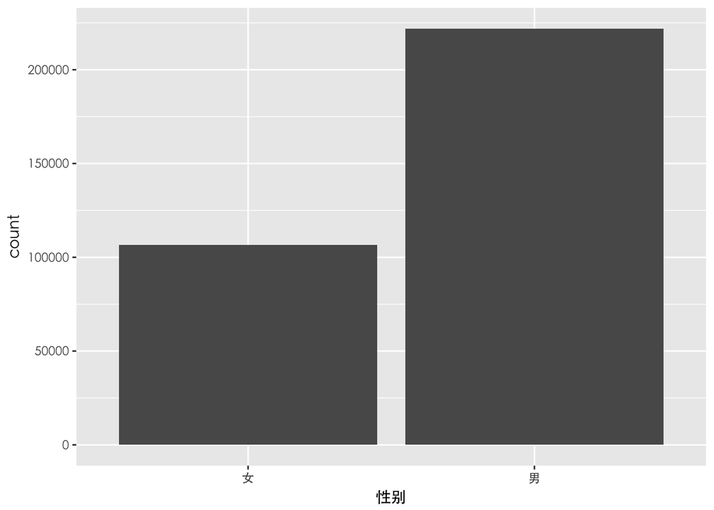

由此可见，男性比例更高。

##### 2.1.2 借款的男性和女性，更偏向于选择怎样的借款期限

```
##    Min. 1st Qu.  Median    Mean 3rd Qu.    Max.
##    1.00    6.00   12.00   10.21   12.00   24.00
```

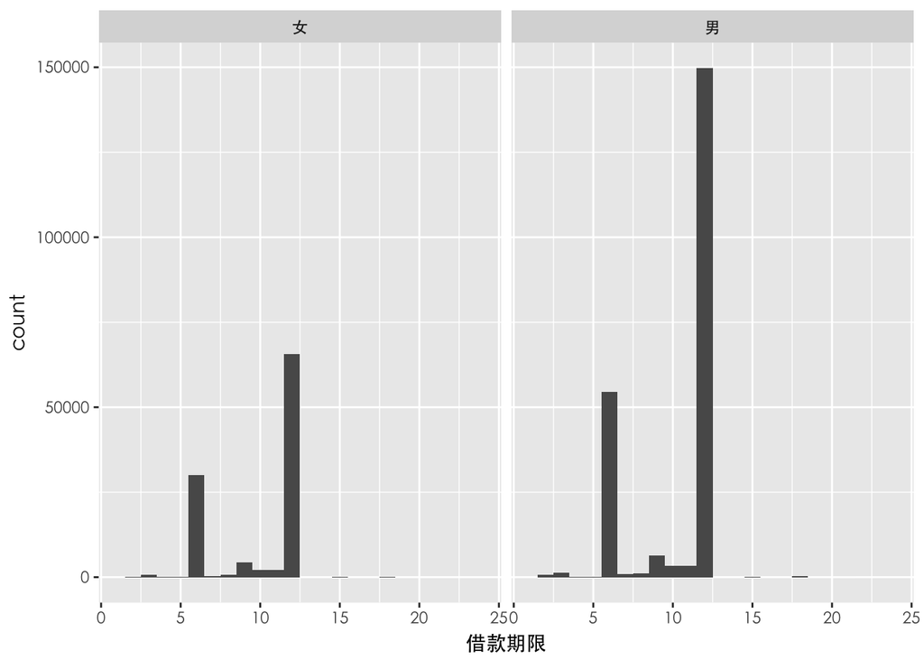

由此可见，男性和女性在选择借款期限上都较为一致，一般选择6期或者12期。

#### 2.2 对LP数据集的观察和分析

贷款的还款状态分布是怎么样的？

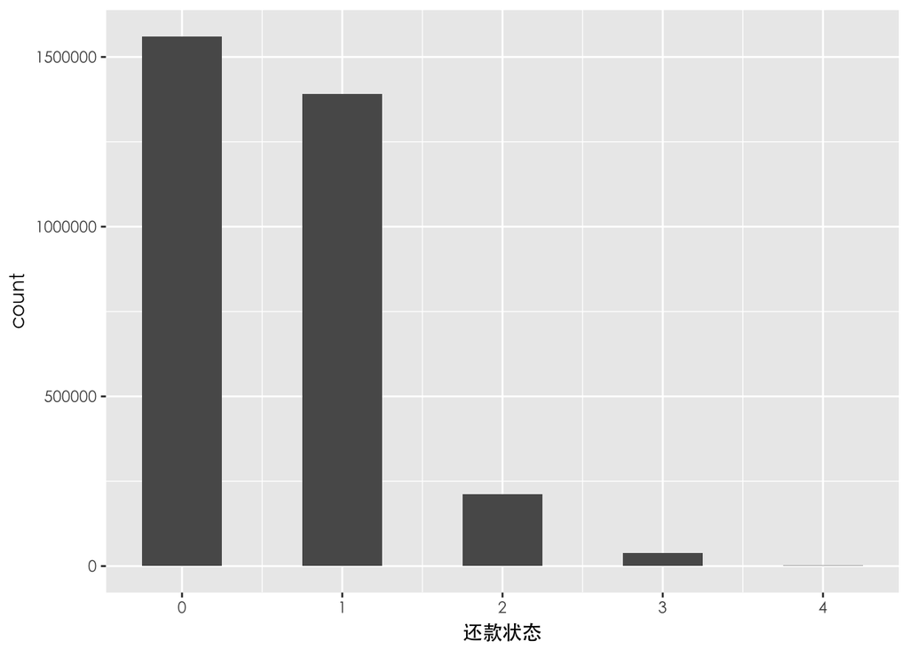

由此可见，由此可见，大部分是未还款或“已正常还款”，有一定量的“已逾期还款”，“已提前还清该标全部欠款’”和“已部分还款”比较少。

#### 2.3 对LCIS数据集的观察和分析

大部分借款人的初始评级分布是怎样的？

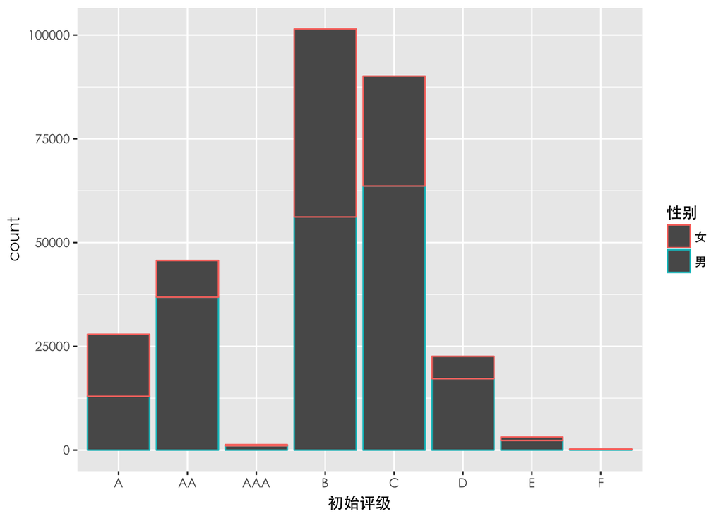

结论：大部分借款人的初始评级为B或者C。男性的C类较多，女性的B类较多。

### 3. 你认为数据集内哪些其他特征可以帮助你探索兴趣特点？

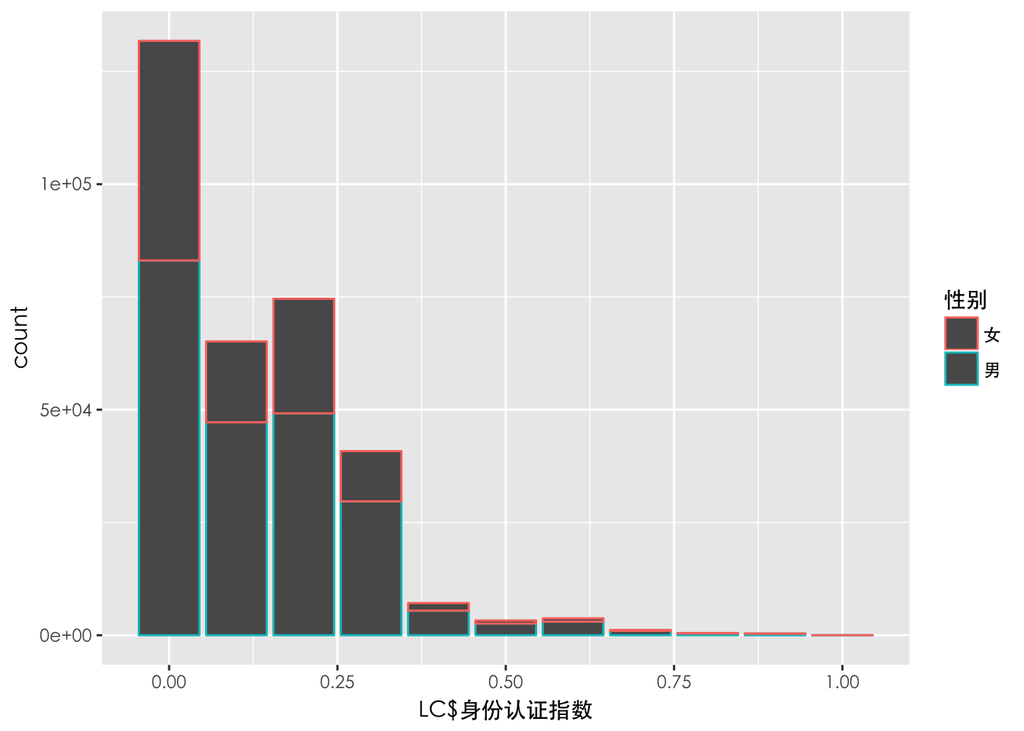

```
##    Min. 1st Qu.  Median    Mean 3rd Qu.    Max.
##  0.0000  0.0000  0.1000  0.1278  0.2000  1.0000
```

结论：平均值分布为0.13分，中位数为0.1分。结论：由此发现，大量的借款人并没有进行身份认证。应当采用用户运营手段来促使借款人认证，获取足够数据源便于分析。

### 5. 在已经探究的特性中，是否存在任何异常分布？你是否对数据进行一些操作，如清洁、调整或改变数据的形式？如果是，你为什么会这样做？

# 双变量分析

### 探讨你在这部分探究中观察到的一些关系。这些感兴趣的特性与数据集内其他特性有什么区别？

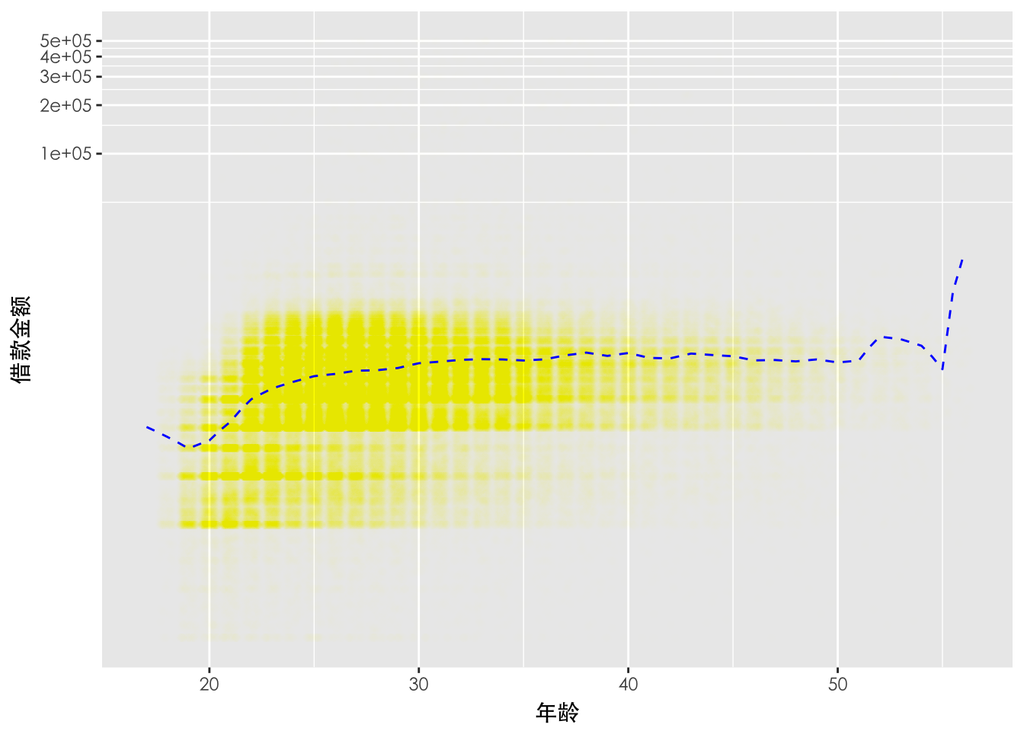

```r
# 借款金额用 以10为底的对数 来处理
```

3. 与历史成功单次借款金额的关系

定义了 历史成功单次借款金额(Historical successful single loan amount)简写为 hs1LA

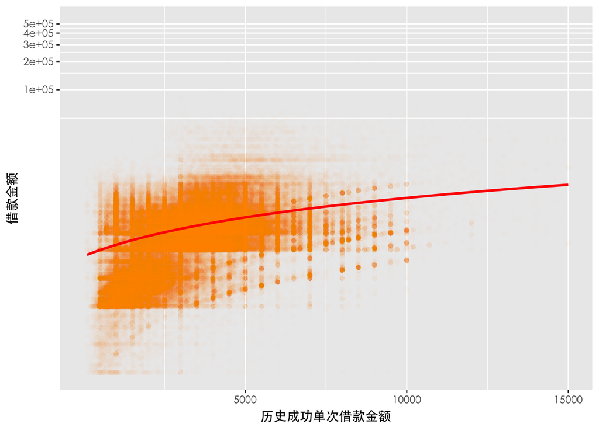

```r
# 定义hs1LA
LC$hs1LA <- ifelse(LC$历史成功借款次数 > 0, LC$历史成功借款金额 / LC$历史成功借款次数, 0)

# hs1LA与借款金额的关系，其中借款金额依旧用 以10为底的对数 来处理
ggplot(aes(x = LC$hs1LA, y = LC$借款金额), data = LC) +
    geom_point(alpha = 1/150, position = position_jitter(h = 0), color = 'orange') +
    coord_trans(y = "log10") +
    xlim(1,15000) +
    xlab("历史成功单次借款金额") +
    ylab("借款金额") +
    theme(text = element_text(family = "STHeiti")) +
    geom_smooth(method = 'lm', color = 'red')
```

### 你是否观察到主要特性与其他特性之间的有趣关系？

### 你发现最强的关系是什么？

# 多变量绘图选择

在分析逾期率之前，发现“标当前状态”一列中有不整洁数据存在，一些数字而不是表示当期状态的字符串（如‘正常还款中’，‘逾期中’，‘已还清’，‘已债转’）。利用filter()将这些不整洁数据剔除。

则不同电商平台下的逾期率

```r
as.data.frame(table(LCIS_APP闪电$标当前状态))
```

[output not shown]

[output cut: 220 more lines]

```r
as.data.frame(table(LCIS_其他$标当前状态))
```

[output not shown]

[output cut: 220 more lines]

```r
as.data.frame(table(LCIS_应收安全标$标当前状态))
```

[output not shown]

[output cut: 220 more lines]

```r
as.data.frame(table(LCIS_普通$标当前状态))
```

[output not shown]

[output cut: 220 more lines]

```r
as.data.frame(table(LCIS_电商$标当前状态))
```

[output not shown]

[output cut: 220 more lines]

```r
# set.seed(1234)
# LCIS_clean_subset <- LCIS_clean[, c()]  ##此行需要完善，挑选 生成热图的列
# ggpairs(LCIS_clean_subset[sample(nrow(LCIS_clean_subset),1000),])
```

# 多变量分析

### 探讨你在这部分探究中观察到的一些关系。通过观察感兴趣的特性，是否存在相互促进的特性？

### 这些特性之间是否存在有趣或惊人的联系呢？

### 选项：你是否创建过数据集的任何模型？讨论你模型的优缺点。

# 定稿图与总结

### 绘图一

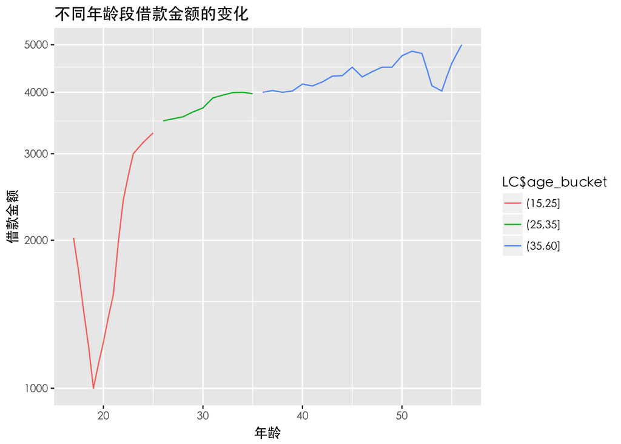

### 描述一

不同年龄段与其借款金额的变化关系,年龄越大，即可额度越多。

### 绘图二

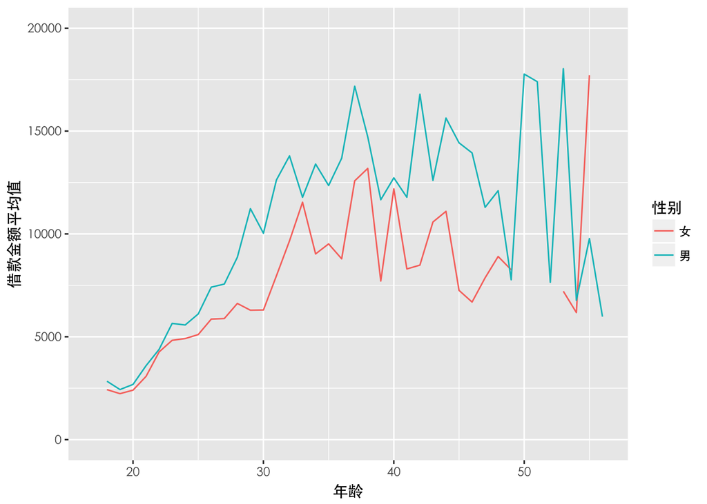

[figure not shown]

### 绘图三

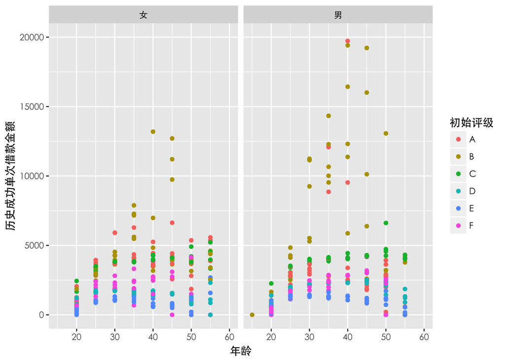

### 描述三

不同初始等级情况下，历史成功单次借款金额随着年龄有怎样的变化？